# Deconvolution

Spatial transcriptomics

Deconvolution

Cell type annotation

This lesson breaks down multi-cell spatial spots into estimated cell type proportions using deconvolution methods such as RCTD with single-cell RNA-seq references. This lesson covers reference preparation, model fitting and visualization of cell composition across tissue.

Author

Noor Sohail

Published

July 22, 2025

Keywords

RCTD, scRNA-seq, Cell proportions

Approximate time: 40 minutes

## Learning objectives

In this lesson, we will:

- Load and investigate our reference dataset used for cell type annotation
- Convert our Seurat object into an RCTD data structure
- Deconvolve bins to assign cell types and assess the annotation

## Overview of lesson

While the clusters are helpful in identifying groups of bins that are similar to one another, we have not yet determined the cell type for each bin. For sequencing-based methods, deconvolution is a great first step in determining the cell type for each spot, given that a bin may have multiple cells contained within it. We will be using the method Robust Cell Type Deconvolution (RCTD) to assign cell type labels for each bin. These deconvolution outputs are reused in subsequent analyses, such as cell–cell communication.

## What is deconvolution?

The single-digit micron resolution is a big technological improvement over Visium’s original ∼55μm spots. Because a single spot could include several cell types, the dataset is not straightforward to annotate. As a result, many methods **model each spot as a mixture**, assigning proportion values for each cell type within that spot. Each spot is represented as a piechart showing proportions of the cell type composition.

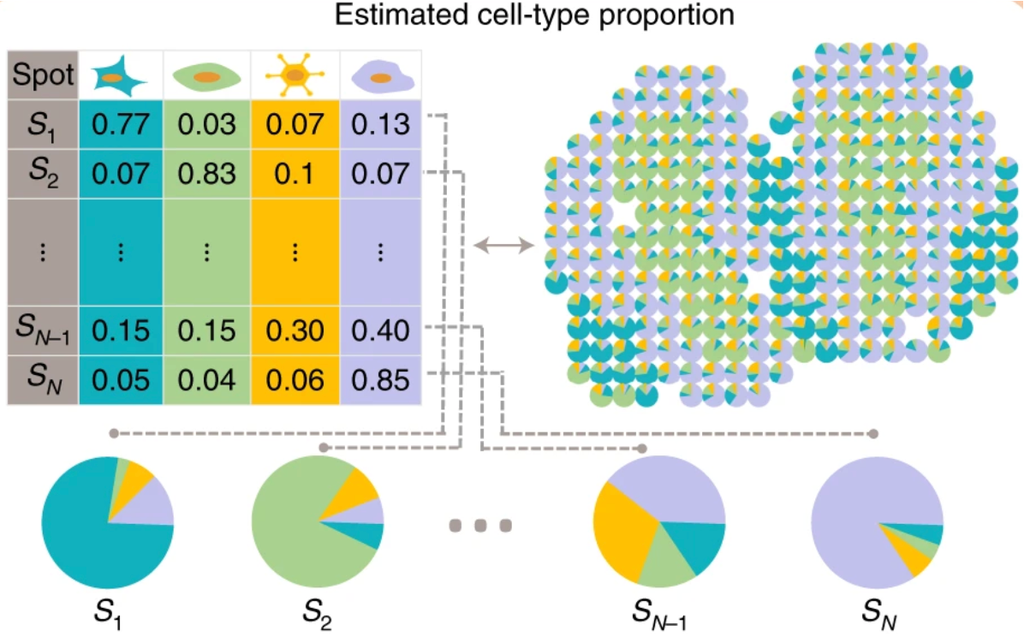

Figure 1: Schematic showing how, in sequencing-based spatial transcriptomics, each bin may be a mixture of cells and cell types. *Image source: [Ma et al. (2022)](https://www.nature.com/articles/s41587-022-01273-7)*

While Visium HD reduces bin size to approach single-cell resolution, it is important to note that this sequencing-based spatial transcriptomics captures RNA from a defined spatial area rather than from isolated cells. As a result, transcripts from multiple cells overlapping in a bin would be pooled and sequenced together. This means that even small bins may contain mixed cellular signals, which has important implications for downstream analyses, such as differential gene expression.

**Imaging-based technologies**

It is important to note that up until this point, the entire workflow we have been using would work for either imaging- or sequencing-based spatial technologies. **Deconvolution is not an appropriate step for imaging-based technologies.**

This is because when we work with imaging-based technologies, we are using *single-cells* after segmentation. Therefore it does not make sense to model a mixture of cell types when the input is single cells. As a result, the annotation for these datasets follows a similar workflow as celltyping a single-cell experiment.

To annotate your dataset, we recommend to do a mixture of the following:

- Use [marker genes from the literature](https://hbctraining.github.io/Intro-to-scRNAseq/lessons/11_clustering_quality_control.html#exploring-known-cell-type-markers) that are specific to a cell type
- Identify [top genes per cluster](https://hbctraining.github.io/Intro-to-scRNAseq/lessons/13_marker_identification.html) to map cell types to clusters
- Apply automatic celltyping algorithms (i.e [Azimuth](https://azimuth.hubmapconsortium.org/), [CellTypist](https://www.celltypist.org/encyclopedia/Immune/v2), [SingleR](https://bioconductor.org/packages/devel/bioc/vignettes/SingleR/inst/doc/SingleR.html), etc.)